# Canada’s Path to an EV Future

- Show All Code
- Hide All Code
- View Source

Where Canada stands in the global shift to zero emission vehicles

R

Author

Skylar Carroll

Published

October 27, 2024

###### For a high-level presentation of the findings, [click here.](https://www.linkedin.com/feed/update/urn:li:activity:7259295545637101568/)

As society continues to rapidly shift to cleaner transportation, how near are we to an EV-dominant future and how fast is this transformation taking place both in Canada, and globally? This analysis highlights how many of Canada’s new vehicle registrations are already electric compared to global leaders, and attempts to measure the speed of this transition.

With data from [Stats Canada](https://www150.statcan.gc.ca/t1/tbl1/en/tv.action?pid=2010002401) and [International Energy Agency](https://www.iea.org/reports/global-ev-outlook-2023), we’ll answer these questions to understand when EVs might dominate Canadian roads.

## Setting up the R environment

The following libraries will allow us to import, tidy, and visualize the data.

```r
# to style code according to the tidyverse style guide
# install.packages("styler")

library(knitr) # for rendering this document
opts_chunk$set(message = FALSE, warning = FALSE, cache = FALSE)
options(width = 100, dplyr.width = 100)

library(tidyverse) # for cleaning the data
library(lubridate) # date handling
library(forcats) # factor manipulation
library(janitor) # tidying variables
library(kableExtra) # creating data tables
```

## Importing and validating the data

There are two Statistics Canada datasets for new motor vehicle registrations (NMVR) with breakdowns by fuel type, geography, and vehicle type. One published in 2021 which is yearly data, and the most recent quarterly data up to and including Q2 2024. The global data is a single csv with car sales with electric and non-electric values.

```r
# output hidden

# reading in the Stats Canada datasets.

# https://www150.statcan.gc.ca/t1/tbl1/en/tv.action?pid=2010002101
# citation: Statistics Canada. Table 20-10-0021-01  New motor vehicle registrations, inactive
statscan2021 <- read_csv("data/statscan_2021.csv")

# https://www150.statcan.gc.ca/t1/tbl1/en/tv.action?pid=2010002401
# citation: Statistics Canada. Table 20-10-0024-01  New motor vehicle registrations, quarterly
statscan2024 <- read_csv("data/statscan_2024.csv")

# now for the global data
# https://ourworldindata.org/electric-car-sales
# citation: International Energy Agency. Global EV Outlook 2024. – processed by Our World in Data
statsglobal_csv <- read_csv("data/car-sales.csv")
```

This code is inspecting the structure of the data to see how we should proceed.

```r
# output hidden

# check structure
str(statscan2021)
head(statscan2021)

str(statscan2024)
head(statscan2024)

str(statsglobal_csv)
summary(statsglobal_csv)

statsglobal_csv |>
  select(Entity) |>
  distinct() # Important: this reveals a 'World' geography with totals.
```

Both Stats Canada datasets have the same structure except for granularity and the ref_date column. Before joining the data, the date columns must be made compatible.

The summary function can be used to validate the date and value ranges, to check for NA or missing data, and for comparing the categories.

```r
# The 2021 data only has years of class dbl while the 2024 data has yyyy-mm as class chr
# validate date range and distinct categories.
statscan2021 |>
  # we are only interested in these variables
  select(REF_DATE, GEO, `Fuel type`, `Vehicle type`) |>
  mutate(
    geo = as.factor(GEO), # create factors for the summary function
    fuel_type = as.factor(`Fuel type`),
    vehicle_type = as.factor(`Vehicle type`),
    .keep = "unused" # don't include referenced columns
  ) |>
  summary()
```

```
    REF_DATE                                      geo                         fuel_type
 Min.   :2011   Alberta                             : 385   All fuel types         :605
 1st Qu.:2013   British Columbia and the Territories: 385   Battery electric       :605
 Median :2016   Canada                              : 385   Diesel                 :605
 Mean   :2016   Manitoba                            : 385   Gasoline               :605
 3rd Qu.:2019   New Brunswick                       : 385   Hybrid electric        :605
 Max.   :2021   Newfoundland and Labrador           : 385   Other fuel types       :605
                (Other)                             :1925   Plug-in hybrid electric:605
                 vehicle_type
 Multi-purpose vehicles:847
 Passenger cars        :847
 Pickup trucks         :847
 Total, vehicle type   :847
 Vans                  :847
```

```r
statscan2024 |>
  select(REF_DATE, GEO, `Fuel type`, `Vehicle type`) |>
  mutate(
    ref_date = ym(REF_DATE), # convert to date for the summary function
    geo = as.factor(GEO),
    fuel_type = as.factor(`Fuel type`),
    vehicle_type = as.factor(`Vehicle type`),
    .keep = "unused"
  ) |>
  summary()
```

```
    ref_date                                            geo                         fuel_type
 Min.   :2017-01-01   Alberta                             :1050   All fuel types         :1650
 1st Qu.:2018-10-01   British Columbia and the Territories:1050   Battery electric       :1650
 Median :2020-08-16   Canada                              :1050   Diesel                 :1650
 Mean   :2020-08-15   Manitoba                            :1050   Gasoline               :1650
 3rd Qu.:2022-07-01   New Brunswick                       :1050   Hybrid electric        :1650
 Max.   :2024-04-01   Newfoundland and Labrador           :1050   Other fuel types       :1650
                      (Other)                             :5250   Plug-in hybrid electric:1650
                 vehicle_type
 Multi-purpose vehicles:2310
 Passenger cars        :2310
 Pickup trucks         :2310
 Total, vehicle type   :2310
 Vans                  :2310
```

We can see from the summaries that the vehicle types and fuel types of both datasets are equal but not all of the distinct geographies are listed. Let’s check and compare the distinct geographies to make sure joining the data goes smoothly.

```r
# checking all of the distinct geographies in the dataset
stats1 <- statscan2021 |>
  select(GEO) |>
  distinct()

stats2 <- statscan2024 |>
  select(GEO) |>
  distinct()

all.equal(stats1, stats2)
```

```
[1] TRUE
```

## Tidying the data

Before joining the data ensure all variables are shared by creating a ‘year’, ‘quarter’, and ‘ref_date’ variable where needed.

```r
statscan2021_clean <- statscan2021 |>
  clean_names("snake") |>

  # Only keep needed variables
  select(ref_date, geo, fuel_type, vehicle_type, value) |>

  # create a separate year column
  rename(year = ref_date) |>

  # and ref_date and quarter columns to properly union the two datasets
  # Note: any quarterly analysis may not work as expected without first
  # filtering out the NAs removing years without quarterly data
  mutate(
    ref_date = NA,
    quarter = NA
  )


statscan2024_clean <- statscan2024 |>
  clean_names("snake") |>

  # Only keep needed variables
  select(ref_date, geo, fuel_type, vehicle_type, value) |>

  # create year, quarter columns and mutate ref_date to class 'date'.
  mutate(
    quarter = quarter(ym(ref_date)),
    ref_date = ym(ref_date),
    year = year(ref_date)
  )
```

In the meta-data, it states that, “Data for Newfoundland and Labrador, Nova Scotia and Alberta are currently not available…” This code checks to ensure these provinces don’t have any data.

```r
# create object with NA geographies

na_geo <- c("Newfoundland and Labrador", "Alberta", "Nova Scotia")

# check if there are only NAs for those provinces before dropping rows.
statscan2021_clean |>
  filter(geo %in% na_geo, is.na(value) == FALSE)
statscan2024_clean |>
  filter(geo %in% na_geo, is.na(value) == FALSE)
```

| year | geo | fuel_type | vehicle_type | value | ref_date | quarter |
| --- | --- | --- | --- | --- | --- | --- |

| ref_date | geo | fuel_type | vehicle_type | value | quarter | year |
| --- | --- | --- | --- | --- | --- | --- |

Zero rows output confirms we can safely remove observations for those provinces.

```r
# drop the observations with provinces in 'na_geo'
statscan2021_clean <- statscan2021_clean |>
  filter(!(geo %in% na_geo))

statscan2024_clean <- statscan2024_clean |>
  filter(!(geo %in% na_geo))
```

To join the data, filter out the overlapping years in favour of the higher granularity in the quarterly data set, then the observations can be stacked with a union.

```r
# only include years prior to 2017
statscan2021_clean <- statscan2021_clean |>
  filter(year < "2017")

# union the datasets and check the result
(statscan_nmvr <- statscan2024_clean |>
  union(statscan2021_clean) |>

  # we won't need vehicle types
  filter(vehicle_type == "Total, vehicle type") |>
  select(-vehicle_type) |>

  # adding in superscript for a table footnote
  mutate(
    fuel_type = case_when(str_detect(fuel_type, "Other fuel types") ~ "Other fuel types\u00B2",
      .default = fuel_type
    ),

    # create new column to group fuel types into either EV or non-EV
    ev_fuel = case_when(fuel_type %in% c("Battery electric", "Plug-in hybrid electric") ~ "EV",
      !(fuel_type %in% c("All fuel types", "Battery electric", "Plug-in hybrid electric")) ~ "Non-EV",
      .default = fuel_type
    )
  )
)
```

| ref_date | geo | fuel_type | value | quarter | year | ev_fuel |
| --- | --- | --- | --- | --- | --- | --- |
| 2017-01-01 | Canada | All fuel types | 425043 | 1 | 2017 | All fuel types |
| 2017-01-01 | Canada | Gasoline | 403087 | 1 | 2017 | Non-EV |
| 2017-01-01 | Canada | Diesel | 14283 | 1 | 2017 | Non-EV |
| 2017-01-01 | Canada | Battery electric | 1664 | 1 | 2017 | EV |
| 2017-01-01 | Canada | Hybrid electric | 4185 | 1 | 2017 | Non-EV |
| 2017-01-01 | Canada | Plug-in hybrid electric | 1824 | 1 | 2017 | EV |
| 2017-01-01 | Canada | Other fuel types² | 0 | 1 | 2017 | Non-EV |
| 2017-01-01 | Prince Edward Island | All fuel types | 1533 | 1 | 2017 | All fuel types |
| 2017-01-01 | Prince Edward Island | Gasoline | 1495 | 1 | 2017 | Non-EV |
| 2017-01-01 | Prince Edward Island | Diesel | 27 | 1 | 2017 | Non-EV |

[output cut: 2006 more lines]

## Preparing the data

**1. Table data frame**

Now the data is ready to be prepared for visualizing by creating some data frames starting with a table.

```r
####################################################
#########  Kable Table ############################

# for easily referencing BC
bc_geo <- "British Columbia and the Territories"

# preparing data for a table
statscan_nmvr_kable <- statscan_nmvr |>

  # keep only Canada and BC. Take a snapshot
  # of the past five and a half years (2024 is up to Q2) only.
  filter(
    geo %in% c("Canada", bc_geo),
    year >= 2019
  ) |>
  group_by(geo, fuel_type, year) |>
  summarise(units = sum(value)) |>

  # pivoting to a wide format for the table
  pivot_wider(names_from = year, values_from = units) |>
  arrange(desc(geo), desc(`2023`)) |>
  ungroup()

# custom column headers for the table
my_col_names <- c(" ", " ", " ", "Units", " ", " ", " ")
new_headers <- c("Fuel Type" = 1, "2019" = 1, "2020" = 1, "2021" = 1, "2022" = 1, "2023" = 1, "2024" = 1)
```

**2. Column chart data frame**

The following code is for a column chart with factors and labels for highlighting specific data.

```r
####################################################
#########  Column chart ###########################

# data frame for column chart
nmvr_province <- statscan_nmvr |>
  filter(
    ev_fuel != "All fuel types", # Important: this is a totals row
    geo != "Canada",
    year == 2023
  ) |>
  group_by(geo, ev_fuel) |>
  summarise(nmvr = sum(value)) |>
  mutate(share = nmvr / sum(nmvr) * 100)

# reordering factor levels
nmvr_province_lvls <- nmvr_province |>
  filter(ev_fuel == "EV") |>
  arrange(share) |>
  pull(geo)

nmvr_province <- mutate(nmvr_province,
  geo = factor(geo, levels = nmvr_province_lvls)
)

# creating df for highlighting and labeling in plots
nmvr_bc <- nmvr_province |>
  filter(geo == bc_geo) |>
  mutate(label = ifelse(ev_fuel == "EV", round(share / 100, 2), NA))

# bc labels
nmvr_bc_ev <- nmvr_bc |>
  filter(ev_fuel == "EV") |>
  pull(label)

# ev levels
nmvr_ev_lvls <- nmvr_province |>
  filter(ev_fuel == "EV") |>
  arrange(nmvr) |>
  pull(geo)

# ev labels
nmvr_ev_labs <- nmvr_province |>
  filter(ev_fuel == "EV") |>
  arrange(desc(nmvr)) |>
  head(n = 3)
```

**3. Timeseries data frames**

Data frames for quarterly and yearly plots.

```r
####################################################
#########  Timeseries #############################

# function for common share transformation
share_calc <- function(df, g, scale) {
  return(df |>
    filter(geo == g) |>
    group_by({{ scale }}, ev_fuel) |>
    summarise(nmvr = sum(value)) |>
    mutate(share = nmvr / sum(nmvr)) |>
    filter(ev_fuel == "EV"))
}

# data frame for quarterly timeseries
nmvr_quarterly_share <- statscan_nmvr |>
  filter(
    fuel_type != "All fuel types",
    # only the quarterly data
    !(is.na(quarter))
  )

# one for BC
nmvr_quarterly_share_bc <- share_calc(nmvr_quarterly_share, bc_geo, ref_date)

# one for Canada
nmvr_quarterly_share_can <- share_calc(nmvr_quarterly_share, "Canada", ref_date)

# finding the year over year rate of EV share growth
nmvr_share_rate <- share_calc(
  filter(
    statscan_nmvr,
    fuel_type != "All fuel types",
    year != 2024
  ),
  "Canada", year
) |>
  arrange(year) |>
  ungroup() |>
  mutate(share_growth = (share - lag(share)) / lag(share) * 100)
```

**4. Global data**

The following code prepares data frames for plotting and statistics of the global data.

```r
####################################################
#########  Global Data ############################

# tidying global data
statsglobal_clean <- statsglobal_csv |>
  select(-Code) |>
  clean_names("snake") |>
  mutate(
    electric_cars = electric_cars_sold,
    non_electric_cars = round(non_electric_car_sales),
    ev_yearly_share = electric_cars / (electric_cars + non_electric_cars),
  ) |>
  pivot_longer(cols = ends_with("cars"), names_to = "type", values_to = "sales")

# ordering global data for factor levels
top_ev_share_global_levels <- statsglobal_clean |>
  filter(year == max(year)) |>
  summarize(.by = c(entity, year), ev_share = max(ev_yearly_share)) |>
  arrange(desc(ev_share)) |>
  select(entity) |>
  pull(entity)


# Creating data frame and factor levels for global share plot
ev_share_global <- statsglobal_clean |>
  mutate(entity = factor(entity, levels = top_ev_share_global_levels)) |>
  filter(as.integer(entity) < 6 | entity == "Canada") |>
  group_by(entity, year) |>

  # we take the max and not the sum of ev_yearly_share here because the share
  # was calculated before pivoted, creating repeated values for each 'type'
  summarise(ev_share = max(ev_yearly_share))

# finding the max value for labelling
max_share <- ev_share_global |>
  group_by(entity) |>
  summarise(share = max(ev_share))

# creating new column for highlighting Canada
ev_share_global_fill <- ev_share_global |>
  mutate(is_canada = as.character(entity == "Canada"))

####################################################
# creating data frame for share growth stats
global_share_growth <- statsglobal_clean |>
  filter(
    entity == "World",
    type == "electric_cars"
  ) |>
  arrange(year) |>
  mutate(share_growth = (ev_yearly_share - lag(ev_yearly_share)) / lag(ev_yearly_share) * 100)
```

**5. Theme and palette**

To maintain a consistent style, we can prepare a theme to style the plots and define an accessible colour palette.

```r
# output: false
# create a ggplot custom theme

theme <- theme_minimal() +
  theme(
    axis.title.x = element_text(margin = margin(t = 3, b = 3)),
    axis.title.y = element_blank(),
    strip.background = element_blank(),
    axis.line.x = element_line(color = "gray"),
    axis.line.y = element_line(color = "gray"),
    axis.ticks.x = element_line(color = "gray"),
    legend.title = element_blank(),
    legend.position = "top",
    legend.key.size = unit(4, "mm"),
    legend.justification.top = -0.5,
    legend.text.position = "left",
    legend.box.margin = margin(t = 0, b = 0, unit = "pt"),
    title = element_text(hjust = 1),
    plot.title.position = "plot",
    plot.caption.position = "plot",
    plot.margin = margin(10, 10, 10, 10),
    plot.caption = element_text(hjust = 0.1, vjust = 0.1),
  )

theme_set(theme)

# create accessible colour palette
clr_plt <- hcl.colors(5, palette = "blue-red")
# "#023FA5" "#A1A6C8" "#E2E2E2" "#CA9CA4" "#8E063B"
```

## Understanding the data

In BC there were **35,887** battery electric NMVR in the year of 2023, more than double from **12,288** in 2019, only 4 years prior. Canada as a whole saw an even greater increase in battery electric NMVR over the past 4 years quadrupling from **35,523** in 2019 to **143,661** in 2023. Keep in mind, 2024 data only includes Q1 and Q2, suggesting we are well on the way to once again breaking last year’s EV registration record.

```r
statscan_nmvr_kable <- statscan_nmvr_kable |>

  # these mutate calls are for highlighting the specific values in the table
  # using cell_spec()
  mutate(
    `2023` = cell_spec(scales::comma(`2023`), "html",
      color = case_when(`2023` == 35887 ~ clr_plt[1],
        `2023` == 143661 ~ clr_plt[5],
        .default = "black"
      ),
      bold = case_when(`2023` == 35887 | `2023` == 143661 ~ TRUE,
        .default = FALSE
      )
    )
  ) |>
  mutate(
    `2019` = cell_spec(scales::comma(`2019`), "html",
      color = case_when(`2019` == 12288 ~ clr_plt[1],
        `2019` == 35523 ~ clr_plt[5],
        .default = "black"
      ),
      bold = case_when(`2019` == 12288 | `2019` == 35523 ~ TRUE,
        .default = FALSE
      )
    )
  )

# building a table for BC
statscan_nmvr_kable |>
  filter(geo == bc_geo) |>
  select(-geo) |>
  kbl(
    escape = FALSE, "html",

    # we are using custom column names
    col.names = my_col_names,
    format.args = list(big.mark = ","), table.attr = "quarto-disable-processing=true", # disable quarto processing to avert bug that ignores styling
    align = c("l", "r", "r", "r", "r", "r", "r")
  ) |>
  kable_styling(bootstrap_options = c("hover", "condensed"), html_font = "helvetica") |>
  column_spec(1, width_min = "11em", bold = TRUE, border_right = TRUE) |>
  row_spec(0, bold = TRUE, background = clr_plt[3], align = "r") |>

  # highlight the EV rows
  row_spec(c(3), background = clr_plt[3]) |>

  # adding more custom headers
  add_header_above(new_headers, background = clr_plt[3], bold = TRUE, align = list("l", "c", "c", "c", "c", "c", "c")) |>
  add_header_above(c("Statistics" = 1, "Number of vehicles" = 6),
    background = clr_plt[3],
    bold = TRUE, align = list("r", "c")
  ) |>
  add_header_above(c("Vehicle type" = 1, "Total, vehicle type\u00B9" = 6),
    background = clr_plt[3],
    bold = TRUE, align = list("r", "c")
  ) |>
  add_header_above(c("Geography" = 1, "British Columbia and the Territories" = 6),
    background = clr_plt[3],
    bold = TRUE, align = list("r", "c")
  ) |>
  footnote(number = c("Total vehicle type excludes buses, trailers, recreational vehicles, motorcycles, snowmobiles, golf carts, etc.", "Other fuel types include liquid propane, natural gas, hydrogen, etc."))
# building a table for Canada
statscan_nmvr_kable |>
  filter(geo == "Canada") |>
  select(-geo) |>
  kbl(
    escape = FALSE, "html",

    # we are using custom column names
    col.names = my_col_names,
    format.args = list(big.mark = ","), table.attr = "quarto-disable-processing=true", # disable quarto processing to avert bug that ignores styling
    align = c("l", "r", "r", "r", "r", "r", "r")
  ) |>
  kable_styling(bootstrap_options = c("hover", "condensed"), html_font = "helvetica") |>
  column_spec(1, width_min = "11em", bold = TRUE, border_right = TRUE) |>
  row_spec(0, bold = TRUE, background = clr_plt[3], align = "r") |>

  # highlight the EV rows
  row_spec(c(3), background = clr_plt[3]) |>

  # adding more custom headers
  add_header_above(new_headers, background = clr_plt[3], bold = TRUE, align = list("l", "c", "c", "c", "c", "c", "c")) |>
  add_header_above(c("Statistics" = 1, "Number of vehicles" = 6),
    background = clr_plt[3],
    bold = TRUE, align = list("r", "c")
  ) |>
  add_header_above(c("Vehicle type" = 1, "Total, vehicle type\u00B9" = 6),
    background = clr_plt[3],
    bold = TRUE, align = list("r", "c")
  ) |>
  add_header_above(c("Geography" = 1, "Canada" = 6),
    background = clr_plt[3],
    bold = TRUE, align = list("r", "c")
  ) |>
  footnote(number = c("Total vehicle type excludes buses, trailers, recreational vehicles, motorcycles, snowmobiles, golf carts, etc.", "Other fuel types include liquid propane, natural gas, hydrogen, etc."))
```

| Geography Vehicle type Statistics Fuel Type | British Columbia and the Territories Total, vehicle type¹ Number of vehicles 2019 | British Columbia and the Territories Total, vehicle type¹ Number of vehicles 2020 | British Columbia and the Territories Total, vehicle type¹ Number of vehicles 2021 Units | British Columbia and the Territories Total, vehicle type¹ Number of vehicles 2022 | British Columbia and the Territories Total, vehicle type¹ Number of vehicles 2023 | British Columbia and the Territories Total, vehicle type¹ Number of vehicles 2024 |
| --- | --- | --- | --- | --- | --- | --- |
| All fuel types | 218,001 | 181,183 | 204,892 | 183,277 | 210,669 | 111,492 |
| Gasoline | 181,447 | 144,587 | 155,742 | 129,999 | 136,575 | 72,339 |
| Battery electric | 12,288 | 12,087 | 18,135 | 24,832 | 35,887 | 17,003 |
| Hybrid electric | 8,598 | 8,715 | 13,936 | 13,174 | 19,844 | 11,164 |
| Diesel | 10,940 | 12,640 | 11,296 | 10,392 | 10,597 | 5,670 |
| Plug-in hybrid electric | 4,692 | 3,124 | 5,783 | 4,866 | 7,751 | 5,303 |
| Other fuel types² | 36 | 30 | 0 | 14 | 15 | 13 |

<sup>1</sup> Total vehicle type excludes buses, trailers, recreational vehicles, motorcycles, snowmobiles, golf carts, etc.  
<sup>2</sup> Other fuel types include liquid propane, natural gas, hydrogen, etc.

| Geography Vehicle type Statistics Fuel Type | Canada Total, vehicle type¹ Number of vehicles 2019 | Canada Total, vehicle type¹ Number of vehicles 2020 | Canada Total, vehicle type¹ Number of vehicles 2021 Units | Canada Total, vehicle type¹ Number of vehicles 2022 | Canada Total, vehicle type¹ Number of vehicles 2023 | Canada Total, vehicle type¹ Number of vehicles 2024 |
| --- | --- | --- | --- | --- | --- | --- |
| All fuel types | 1,930,445 | 1,545,561 | 1,646,604 | 1,513,104 | 1,714,913 | 926,049 |
| Gasoline | 1,776,571 | 1,384,928 | 1,415,128 | 1,233,180 | 1,316,444 | 697,123 |
| Battery electric | 35,523 | 39,036 | 58,952 | 98,620 | 143,661 | 84,260 |
| Hybrid electric | 38,390 | 41,453 | 79,328 | 81,049 | 135,682 | 75,873 |
| Diesel | 59,089 | 64,769 | 65,876 | 75,247 | 74,020 | 38,896 |
| Plug-in hybrid electric | 20,642 | 15,317 | 27,315 | 24,990 | 45,090 | 29,884 |
| Other fuel types² | 230 | 58 | 5 | 18 | 16 | 13 |

<sup>1</sup> Total vehicle type excludes buses, trailers, recreational vehicles, motorcycles, snowmobiles, golf carts, etc.  
<sup>2</sup> Other fuel types include liquid propane, natural gas, hydrogen, etc.

### The provinces

How does BC compare to other provinces though? Which province has the highest share of EV NMVR for 2023?

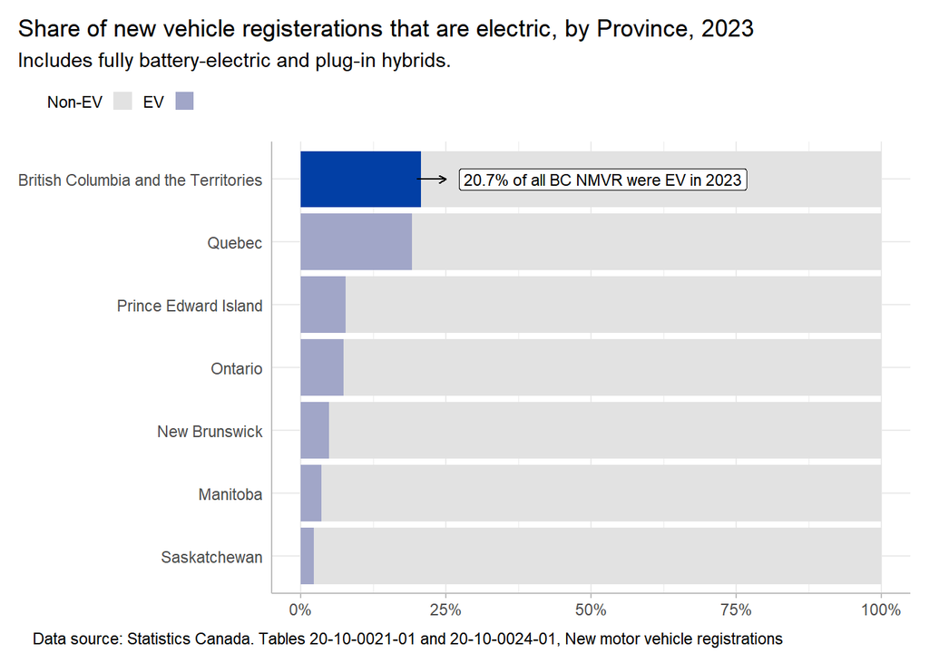

```r
theme_set(theme)

nmvr_province |>
  # to place the ev share against the y axis subtract 'share' from 100
  ggplot(aes(x = geo, y = 100 - share, label = 100 - share, fill = ev_fuel)) +

  # use position "fill" to represent stacked columns as proportion of 100%
  geom_col(position = "fill") +

  # manually fill colour values
  scale_fill_manual(
    values = c(clr_plt[3], clr_plt[2]),
    labels = c("Non-EV", "EV")
  ) +

  # change axis labels to represent percentages
  scale_y_continuous(labels = scales::label_percent()) +

  # add second geom layer to highlight BC
  geom_col(
    data = nmvr_bc, aes(
      x = geo, y = share,
      fill = ev_fuel
    ),
    position = "fill",
    fill = c(clr_plt[1], clr_plt[3])
  ) +
  labs(
    x = NULL, y = NULL,
    title = "Share of new vehicle registerations that are electric, by Province, 2023",
    subtitle = "Includes fully battery-electric and plug-in hybrids.",
    caption = "Data source: Statistics Canada. Tables 20-10-0021-01 and 20-10-0024-01, New motor vehicle registrations"
  ) +
  geom_label(
    data = nmvr_bc, aes(x = geo, y = label, label = str_c(as.character(round(share, 1)), "% of all BC NMVR were EV in 2023")),
    show.legend = F, na.rm = T, nudge_y = 0.31, fill = "white", size = 3
  ) +
  geom_segment(aes(x = bc_geo, y = nmvr_bc_ev - 0.01, yend = nmvr_bc_ev + 0.04),
    data = nmvr_bc, arrow = arrow(length = unit(0.15, "cm")),
    color = "black", linetype = "solid", linewidth = 0.5
  ) +
  coord_flip()
```

### Rate of EV share increase

We can visualize the share of total NMVR that are electric as it changes over time. We can also calculate and plot the rate of share increase.

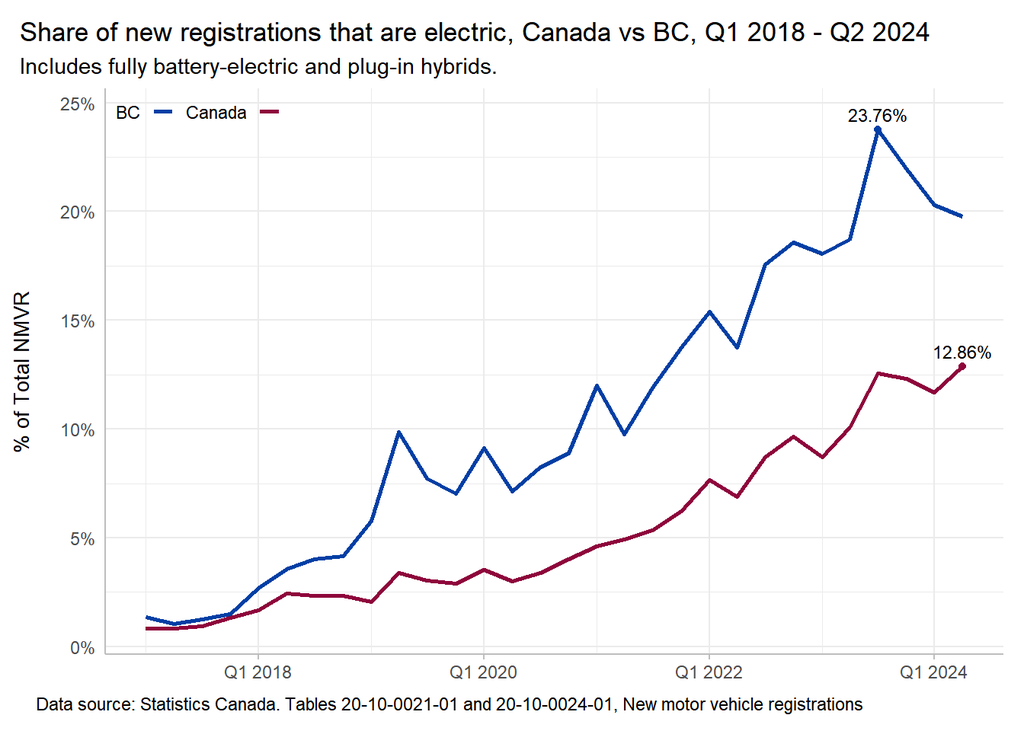

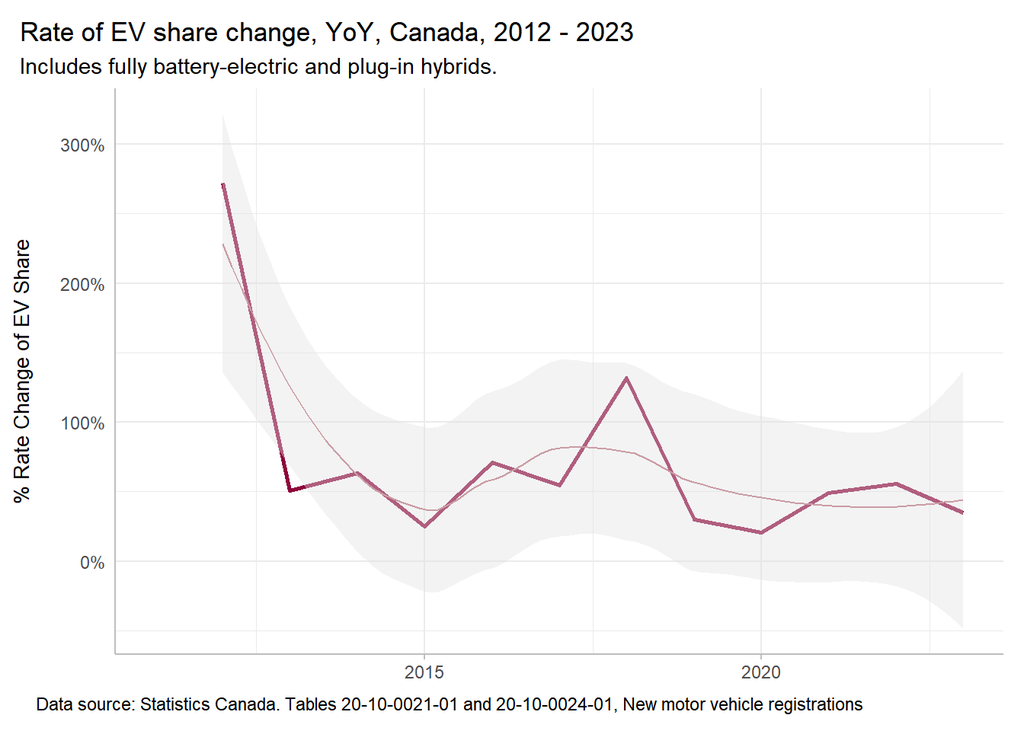

```r
theme_set(theme)

# Create a line plot using the nmvr_quarterly_share dataset
nmvr_quarterly_share_can |>
  ggplot() +

  # adding points to highlight the max values
  geom_point(
    data = nmvr_quarterly_share_can,
    aes(
      x = ref_date, y = ifelse(share == max(share), share, NA),
      color = "Canada"
    ), na.rm = T, show.legend = FALSE
  ) +
  geom_point(
    data = nmvr_quarterly_share_bc,
    aes(
      x = ref_date, y = ifelse(share == max(share), share, NA),
      color = "BC"
    ), na.rm = T, show.legend = FALSE
  ) +

  # Format the y-axis to display percentages with 1% accuracy
  scale_y_continuous(labels = scales::label_percent(accuracy = 1)) +

  # Set custom x-axis scale for dates
  scale_x_date(
    breaks = as.Date(c("2018-01-01", "2020-01-01", "2022-01-01", "2024-01-01")), # Set specific break dates
    labels = c("Q1 2018", "Q1 2020", "Q1 2022", "Q1 2024") # Custom labels for each break
  ) +

  # Add lines for Canada and BC share growth
  geom_line(aes(x = ref_date, y = share, color = "Canada"),
    linewidth = 1, show.legend = TRUE
  ) +
  geom_line(
    data = nmvr_quarterly_share_bc,
    aes(
      x = nmvr_quarterly_share_bc$ref_date,
      y = nmvr_quarterly_share_bc$share, color = "BC"
    ),
    linewidth = 1, show.legend = TRUE
  ) +

  # adding text labels for the max values
  geom_text(
    data = nmvr_quarterly_share_bc, aes(
      x = ref_date, y = share,
      label = ifelse(share == max(share),
        str_c(round(share * 100, 2), "%"),
        ""
      )
    ),
    nudge_y = 0.007, size = 3, show.legend = FALSE
  ) +
  geom_text(
    data = nmvr_quarterly_share_can, aes(
      x = ref_date, y = share,
      label = ifelse(share == max(share),
        str_c(round(share * 100, 2), "%"),
        ""
      )
    ),
    nudge_y = 0.007, size = 3, show.legend = FALSE
  ) +

  # Manually set the color scale and provide labels for the legend
  scale_colour_manual(
    values = c("BC" = clr_plt[1], "Canada" = clr_plt[5]),
    labels = c("BC", "Canada")
  ) +
  labs(
    title = "Share of new registrations that are electric, Canada vs BC, Q1 2018 - Q2 2024",
    subtitle = "Includes fully battery-electric and plug-in hybrids.",
    caption = "Data source: Statistics Canada. Tables 20-10-0021-01 and 20-10-0024-01, New motor vehicle registrations"
  ) +
  ylab(label = "% of Total NMVR") +

  # adjust theme
  theme(
    axis.title.x = element_blank(),
    axis.title.y = element_text(
      size = 10, angle = 90,
      margin = margin(r = 10, unit = "pt"),
      vjust = 3, hjust = 0.5
    ),
    plot.title = element_text(vjust = 0.8),
    legend.title = element_blank(),
    legend.position = "inside",
    legend.key.size = unit(4, "mm"),
    legend.justification.inside = c(0, 1),
    legend.text.position = "left",
    legend.direction = "horizontal",
    legend.box.margin = margin(t = 0, b = 0, unit = "pt"),
  )
# share rate change timeseries just for Canada
nmvr_share_rate |>
  ggplot(aes(x = year, y = share_growth)) +
  geom_line(na.rm = T, linewidth = 1, colour = clr_plt[5]) +

  # add smoothing to make trend more visible
  geom_smooth(method = "loess", formula = "y ~ x", color = clr_plt[4], linewidth = 0.5, fill = clr_plt[3], na.rm = T) +

  # make sure labels are in percent
  scale_y_continuous(labels = scales::label_percent(scale = 1)) +
  labs(
    title = "Rate of EV share change, YoY, Canada, 2012 - 2023",
    subtitle = "Includes fully battery-electric and plug-in hybrids.",
    caption = "Data source: Statistics Canada. Tables 20-10-0021-01 and 20-10-0024-01, New motor vehicle registrations"
  ) +
  ylab(label = "% Rate Change of EV Share") +

  # adjust theme
  theme(
    axis.title.x = element_blank(),
    axis.title.y = element_text(
      size = 10, angle = 90,
      margin = margin(r = 10, unit = "pt"),
      vjust = 3, hjust = 0.5
    ),
    plot.title = element_text(vjust = 0.8)
  )
```

### Global data

How does Canada’s EV share growth compare to the top 5 countries with the highest EV share of total vehicle sales?

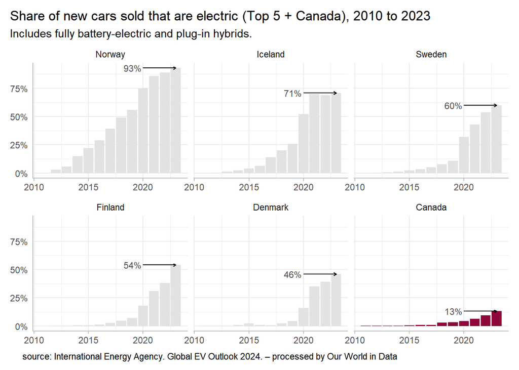

```r
theme_set(theme)

ev_share_global_fill |>
  ggplot(aes(x = year, y = ev_share)) +
  geom_col(aes(fill = is_canada), show.legend = FALSE) +
  scale_fill_manual(values = c("TRUE" = clr_plt[5], "FALSE" = clr_plt[3])) +
  scale_y_continuous(labels = scales::percent) +

  # adding labels of the maximum values with arrows
  geom_segment(aes(x = 2020, xend = 2023, y = share),
    data = max_share, arrow = arrow(length = unit(0.1, "cm")),
    color = "black", linetype = "solid", linewidth = 0.5
  ) +
  geom_text(aes(x = 2020, y = share, label = scales::percent(share)),
    data = max_share,
    hjust = 1.1, color = "grey30", size = 3
  ) +
  labs(
    x = NULL, y = NULL,
    title = "Share of new cars sold that are electric (Top 5 + Canada), 2010 to 2023",
    subtitle = "Includes fully battery-electric and plug-in hybrids.",
    caption = "source: International Energy Agency. Global EV Outlook 2024. – processed by Our World in Data"
  ) +

  # facet wrap showing the x axis labels for each plot with all_x
  facet_wrap(~entity, axes = "all_x")
```

### Estimating when EVs will dominate the market

We can do an estimation of when the majority of cars on the road will be zero emission vehicles by using the summary function to find the distribution of the EV share rate. Then by using the mean and the min values, calculate a range of years representing “best-case” and “minimum” number of years.

To achieve this we will use an exponential growth formula:
$$x(t) = x_0(1 + r)^t$$

The following code will find the range of years using the mean and min rate of growth.

```r
# filter outlier
nmvr_share_rate <- nmvr_share_rate |>
  filter(year > 2012)

summary(nmvr_share_rate$share_growth)
```

```
   Min. 1st Qu.  Median    Mean 3rd Qu.    Max.
  20.87   32.27   50.64   53.36   59.69  132.04
```

We will define a function to calculate exponential growth:

```r
# create a function to find when at the current mean and min rate of share growth
# 100% of NMVR will be EV
ev_saturation_func <- function(df, share, year, rate) {
  # Calculate the average growth rate
  average_growth <- mean(rate[!is.na(rate)]) / 100 # Convert percentage to a decimal

  # using the min rate
  min_growth <- min(rate, na.rm = TRUE) / 100

  # Use the current share and growth rate to predict when it reaches 100%
  current_year <- max(year)
  current_share <- tail(share, 1)

  # Solve for t when share reaches 100% using exponential growth formula
  t <- log(1 / current_share) / log(1 + average_growth)
  v <- log(1 / current_share) / log(1 + min_growth)

  # Calculate the future year
  future_year <- current_year + t
  future_year2 <- current_year + v
  str_c(
    "With a constant rate of ", round(min_growth * 100, 1),
    "% - ", round(average_growth * 100, 1),
    "%, the share of total new vehicles that are electric will reach 100% by ",
    round(future_year), "-", round(future_year2)
  )
}
```

```r
# run function
ev_saturation_func(
  nmvr_share_rate,
  nmvr_share_rate$share,
  nmvr_share_rate$year,
  nmvr_share_rate$share_growth
)
```

```
[1] "With a constant rate of 20.9% - 53.4%, the share of total new vehicles that are electric will reach 100% by 2028-2035"
```

```r
summary(global_share_growth$share_growth)
```

```
   Min. 1st Qu.  Median    Mean 3rd Qu.    Max.    NA's
  8.333  51.852  61.538  97.455  71.429 518.182       1
```

```r
# run function
ev_saturation_func(
  global_share_growth,
  global_share_growth$ev_yearly_share,
  global_share_growth$year,
  global_share_growth$share_growth
)
```

```
[1] "With a constant rate of 8.3% - 97.5%, the share of total new vehicles that are electric will reach 100% by 2026-2044"
```

## Key findings

Assuming the rate of growth remains steady, new vehicle registrations in Canada will be **predominately zero emission within the next 4-11 years**. Although it is unlikely the rate will stay constant, nor is it likely everyone will want to drive an EV, it is evident that Canada is shifting rapidly towards an EV future.